# SnowMelt Decoder — Encoder Heads Greenland 2026

Vertikales Schmelzprofil (IMEI 300434065508020) — Decode, Diagnostik & Plots

Author

Thom Laepple

Published

July 12, 2026

Der **SnowMelt-Kopf** (IMEI **300434065508020**) steht vertikal im Schnee: 24 Knoten mit je NTC1 / NTC2 / NTC3 (TestSB), Abstand 4 cm. Dieses Dokument decodiert die `.bin`-Nachrichten und zeichnet das Schmelz-/Temperaturprofil. Die Kette (IMEI 301434062008130) hat ihr eigenes Dokument `decode_chain.qmd`. Die gemeinsamen Decode- und Kalibrierfunktionen liegen in `decode_core.R`.

```r
source("decode_core.R")
```

## Parameters

Edit this block, then re-render (`Ctrl+Shift+K`).

```r
# Identification is purely by IMEI — the "IMEI: <id>" line in the Cloudloop mail,
# which is also the .bin filename prefix (e.g. 300434065508020-2.bin). For a .bin
# attachment the IMEI is auto-detected from the filename; the head's n_nodes /
# fields / type / spacing then come from head_config[[IMEI]].
IMEI <- ""   # "" = auto-detect from BIN_FILE; set manually for a hex payload

# Path(s) to the .bin attachment(s) from the Cloudloop email ------------------
# One file → single decode. A VECTOR of files → a time series: the newest message
# drives the single-message sections (summary, table, profile), and ALL files
# feed the "Zeitlicher Verlauf" plot. All files must be the same head (same IMEI).
# -2 excluded: head was not yet erected at that time, so its profile is invalid.
BIN_FILE <- setdiff(Sys.glob("../testdata/300434065508020-*.bin"),
                    "../testdata/300434065508020-2.bin")

# OR paste hex payload(s) from the email (set IMEI above, leave BIN_FILE = "")--
MSG1 <- ""
MSG2 <- ""
```

```r
head_config <- list(
  # SnowMelt head, KEYED BY IMEI. `label` is a human name; n_nodes / fields /
  # type / spacing_cm are authoritative for decoding & plots. `calibration` =
  # path to a per-sensor lab table (position,node,ntc,a,b,c,d); NA → decode with
  # the universal mean lab-S4 curve.
  "300434065508020" = list(label = "Snowmelt NEWGRIP", n_nodes = 24L,
                 fields = c("ntc1", "ntc2", "testSB"),
                 type = "snowmelt", spacing_cm = 4L,
                 calibration = "../meta/GRIP_calibration_assignment.csv")
)

# --- Identify head by IMEI ---------------------------------------------------
bin_files <- BIN_FILE[nzchar(BIN_FILE)]
use_bin   <- length(bin_files) > 0L

imei <- if (IMEI != "") {
  IMEI
} else if (use_bin) {
  imeis <- unique(sub("-.*$", "", basename(bin_files)))
  if (length(imeis) > 1L)
    stop("BIN_FILE mixes IMEIs (", paste(imeis, collapse = ", "),
         ") — a time series must be one head.")
  imeis
} else {
  stop("Set IMEI (hex payload) or BIN_FILE (.bin attachment).")
}
cfg  <- head_config[[imei]]
if (is.null(cfg))
  stop(sprintf("IMEI '%s' is not in head_config (this is the SnowMelt document; the chain lives in decode_chain.qmd).", imei))

n_nodes <- cfg$n_nodes
fields  <- cfg$fields

# --- Per-sensor lab calibration (optional, keyed by head) --------------------
# NTC_s4 per sensor where a lab fit exists (and is numerically sane), else the
# universal mean lab-S4 curve (NTC_mean). See decode_core.R::calibrate_channel.
cal_path <- cfg$calibration
lab_cal  <- load_lab_cal(cal_path, n_nodes)     # nested [field][position] coefs, or NULL

n_lab_sensors <- if (is.null(lab_cal)) 0L else
  sum(sapply(names(lab_cal), function(ch)
    if (ch %in% fields) sum(!vapply(lab_cal[[ch]], is.null, logical(1))) else 0L))
n_ntc_sensors <- n_nodes * sum(fields %in% names(ntc_channel))
cal_method <- if (is.null(lab_cal)) "Mittlere Lab-S4-Kurve (universeller Fallback)" else
  sprintf("Lab-S4 pro Sensor (%d/%d) mit Mean-S4-Fallback", n_lab_sensors, n_ntc_sensors)

# --- File-size sanity check (sep vs nosep variant) ---------------------------
if (!use_bin) {
  n_hex_node   <- sum(ifelse(fields %in% c("ntc1", "ntc2", "testSB", "pressure"), 6L, 4L))
  expected_hex <- 8L + 6L + n_nodes * n_hex_node + 4L
} else {
  exp_len <- bin_expected_len(n_nodes, fields)
  for (bf in bin_files) {
    n_file  <- file.info(bf)$size
    surplus <- n_file - exp_len$sep
    ok <- n_file == exp_len$nosep || (surplus >= 0L && surplus <= n_nodes)
    if (!ok)
      warning(sprintf("%s is %d B but IMEI %s (%s) implies %d B (with) or %d B (without separators) for %d nodes — check head_config",
                      basename(bf), n_file, imei, paste(fields, collapse = "/"),
                      exp_len$sep, exp_len$nosep, n_nodes))
    else if (surplus > 0L)
      message(sprintf("%s is %d B (+%d over %d) — likely a defective sensor sending an oversized value; affected field(s) will read NA.",
                      basename(bf), n_file, surplus, exp_len$sep))
  }
}
```

## Decode

```r
library(dplyr)
library(tidyr)
library(ggplot2)
library(patchwork)

if (use_bin) {
  # ---- Binary snowchain path ------------------------------------------------
  # Decode every file, order oldest → newest. The NEWEST message is the "primary"
  # one shown in the single-message sections; all feed "Zeitlicher Verlauf".
  all_bin <- lapply(bin_files, read_snowchain_bin, fields = fields, n_nodes = n_nodes)
  ord       <- order(sapply(all_bin, `[[`, "time_unix"))
  all_bin   <- all_bin[ord]
  bin_files <- bin_files[ord]
  n_msg     <- length(all_bin)

  bin          <- all_bin[[n_msg]]
  primary_file <- bin_files[n_msg]
  time_utc   <- unix2utc(bin$time_unix)
  adc_temp_C <- adc2temp(bin$adc_temp)
  battery_mv <- bin$battery_mv
  battery_lo <- bin$battery_lo
  battery_hi <- bin$battery_hi
  battery_partial <- bin$battery_partial
  bin_fmt    <- if (bin$has_sep) "0x7C-separated" else "no separators"

  nodes <- bin_to_nodes(bin, fields, lab_cal)

} else {
  # ---- Hex email path -------------------------------------------------------
  hex <- toupper(trimws(paste0(MSG1, MSG2)))

  if (nchar(hex) == 0) {
    cat("No payload — set BIN_FILE or paste hex into MSG1 / MSG2 above and re-render.\n")
    knitr::knit_exit()
  }

  if (nchar(hex) != expected_hex) {
    warning(sprintf(
      "Expected %d hex chars (%d bytes) for IMEI %s, got %d. Payload may be incomplete.",
      expected_hex, expected_hex %/% 2L, imei, nchar(hex)
    ))
  }

  schema <- build_schema(n_nodes, fields)
  raw    <- decode_hex(schema, hex)

  time_utc   <- unix2utc(raw$time_unix)
  adc_temp_C <- adc2temp(raw$adc_temp)
  battery_mv <- as.integer(raw$battery_mv)
  battery_lo <- battery_mv; battery_hi <- battery_mv; battery_partial <- FALSE
}
```

## Diagnostics

```r
check <- function(val, lo, hi, label, unit) {
  ok  <- !is.na(val) && val >= lo && val <= hi
  col <- if (ok) "#2ecc71" else "#e74c3c"
  tag <- if (ok) "OK" else "CHECK"
  cat(sprintf('<span style="color:%s">%s</span>  **%s**: %.1f %s  *(expected %g – %g)*\n\n',
              col, tag, label, val, unit, lo, hi))
}
```

**NoteMessage summary — Snowmelt NEWGRIP (IMEI 300434065508020)**

| **Time (UTC)** | 2026-07-12 06:15:57 |
| --- | --- |
| **Battery** | 6912–7167 mV (low byte lost — defective-sensor shift) |
| **ADC temp** | -13.9 °C |
| **Kalibrierung** | Lab-S4 pro Sensor (72/72) mit Mean-S4-Fallback |
| **Source** | binary: 300434065508020-78.bin (no separators) |
| **Messages loaded** | 68 file(s) — newest shown below; see Zeitlicher Verlauf for the series |

```r
check(battery_mv,  5500, 7200, "Battery",  "mV")
```

OK **Battery**: 6912.0 mV *(expected 5500 – 7200)*

```r
check(adc_temp_C, -60,   40,   "ADC temp", "°C")
```

OK **ADC temp**: -13.9 °C *(expected -60 – 40)*

## Node data

```r
if (!use_bin) {
  # Build nodes dataframe from hex-decoded raw list
  ntc_fields <- fields[fields != "gnd"]
  gnd_field  <- if ("gnd" %in% fields) "gnd" else NULL

  nodes <- data.frame(node = seq_len(n_nodes))

  for (f in ntc_fields) {
    col_raw <- paste0("n", nodes$node, ".", f)
    cnts    <- sapply(col_raw, function(nm) raw[[nm]])
    nodes[[paste0(f, "_counts")]] <- cnts          # raw counts (pre-calibration)
    if (f == "pressure") nodes$pressure_hPa  <- pressure2hPa(cnts)
    else                 nodes[[paste0(f, "_C")]] <- calibrate_channel(cnts, f, lab_cal)
  }

  if (!is.null(gnd_field)) {
    col_raw <- paste0("n", nodes$node, ".gnd")
    nodes$gnd <- sapply(col_raw, function(nm) raw[[nm]])
  }
}

# CSV gets the raw counts too; the on-page table stays calibrated for readability.
src_label <- if (use_bin) basename(primary_file) else cfg$label
knitr::kable(nodes |> select(-ends_with("_counts")), digits = 2,
             caption = sprintf("All nodes — %s | %s UTC",
                               src_label, format(time_utc, "%Y-%m-%d %H:%M")))
```

All nodes — 300434065508020-78.bin | 2026-07-12 06:15 UTC

| node | ntc1_C | ntc2_C | testSB_C |
| --- | --- | --- | --- |
| 1 | -16.34 | -16.69 | -16.33 |
| 2 | -16.31 | -16.61 | -16.38 |
| 3 | -16.26 | -16.63 | -16.36 |
| 4 | -16.31 | -16.64 | -16.06 |
| 5 | -16.73 | -16.52 | -16.30 |
| 6 | -16.14 | -16.38 | -16.26 |
| 7 | -16.17 | -16.44 | -16.33 |
| 8 | -16.21 | -16.43 | -16.36 |
| 9 | -16.16 | -16.25 | -16.18 |
| 10 | -16.15 | -16.27 | -16.27 |
| 11 | -16.16 | -16.68 | -16.20 |
| 12 | -16.72 | -16.62 | -16.26 |
| 13 | -16.02 | -16.64 | -15.98 |
| 14 | -16.17 | -16.07 | -15.70 |
| 15 | -15.87 | -16.28 | -15.97 |
| 16 | -15.93 | -16.48 | -16.21 |
| 17 | -15.76 | -16.50 | -15.84 |
| 18 | -15.67 | -16.18 | -15.57 |
| 19 | -15.74 | -16.39 | -16.02 |
| 20 | -15.87 | -16.27 | -15.94 |
| 21 | -15.66 | -16.33 | -16.02 |
| 22 | -15.71 | -15.96 | -15.81 |
| 23 | -15.87 | -16.00 | -15.82 |
| 24 | -15.72 | -16.29 | NA |

## Profil

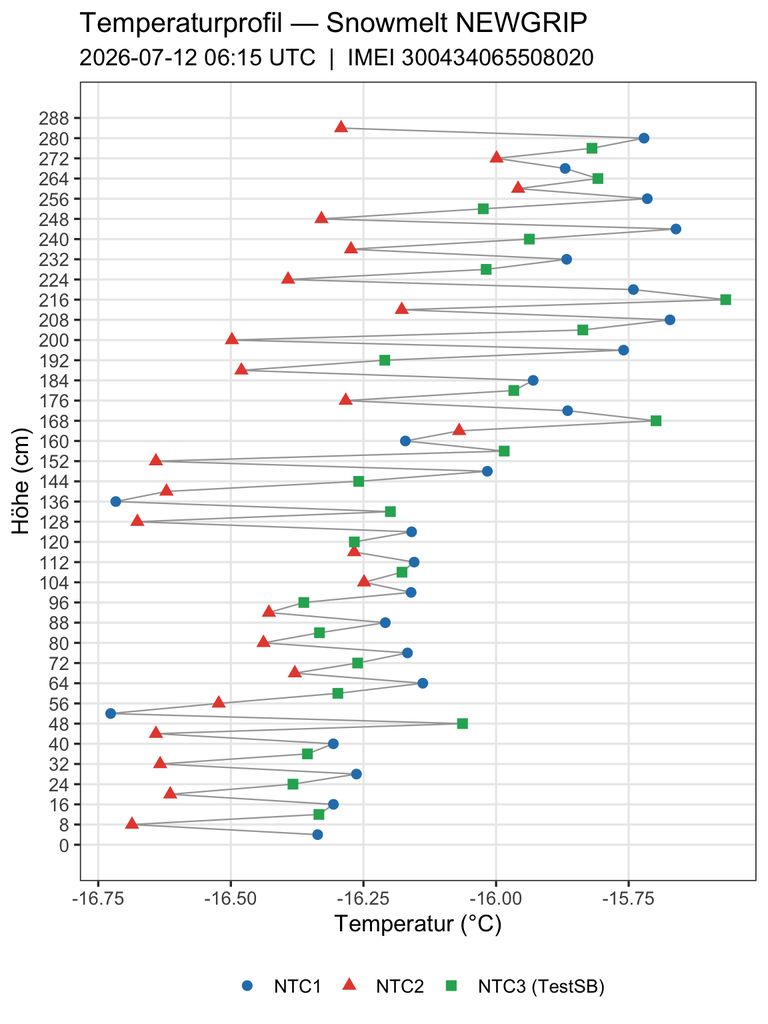

```r
# NTC rank within node: NTC1=1, NTC2=2, TestSB=3; height = (node-1)*3*s + rank*s
s <- cfg$spacing_cm
long <- nodes |>
  select(node, ends_with("_C")) |>
  pivot_longer(ends_with("_C"), names_to = "sensor", values_to = "temp_C") |>
  filter(!is.na(temp_C)) |>          # drop defective sensors (sentinel → NA, e.g. topmost NTC3)
  mutate(
    sensor   = recode(sensor, ntc1_C = "NTC1", ntc2_C = "NTC2", testSB_C = "NTC3 (TestSB)"),
    ntc_rank = case_when(sensor == "NTC1" ~ 1L, sensor == "NTC2" ~ 2L, TRUE ~ 3L),
    hoehe_cm = (node - 1L) * 3L * s + ntc_rank * s
  )

max_h <- n_nodes * 3L * s
ggplot(long, aes(x = temp_C, y = hoehe_cm)) +
  geom_path(data = arrange(long, hoehe_cm), colour = "grey65", linewidth = 0.4) +
  geom_point(aes(colour = sensor, shape = sensor), size = 2.5) +
  scale_y_continuous(
    name   = "Höhe (cm)",
    limits = c(0, max_h),
    breaks = seq(0, max_h, by = max(s, 8L))
  ) +
  scale_x_continuous(name = "Temperatur (°C)") +
  scale_colour_manual(values = c(NTC1 = "#2980b9", NTC2 = "#e74c3c",
                                 "NTC3 (TestSB)" = "#27ae60")) +
  labs(
    title    = sprintf("Temperaturprofil — %s", cfg$label),
    subtitle = sprintf("%s UTC  |  IMEI %s", format(time_utc, "%Y-%m-%d %H:%M"), imei),
    colour   = NULL, shape = NULL
  ) +
  theme_bw(base_size = 13) +
  theme(legend.position = "bottom", panel.grid.minor = element_blank())
```

## Zeitlicher Verlauf

Only shown when more than one `.bin` file is loaded (a time series). Every message contributes; the single-message sections above show the newest one.

```r
multi <- use_bin && exists("all_bin") && n_msg > 1L
```

```r
# Long table across all messages: one row per (time, node, sensor), carrying
# both the calibrated temperature and the raw counts (pre-calibration).
series_wide <- bind_rows(lapply(all_bin, function(b)
  bin_to_nodes(b, fields, lab_cal) |> mutate(time = unix2utc(b$time_unix))))

temp_l <- series_wide |> select(node, time, ends_with("_C")) |>
  pivot_longer(ends_with("_C"), names_to = "sensor", values_to = "temp_C")
cnt_l  <- series_wide |> select(node, time, ends_with("_counts")) |>
  pivot_longer(ends_with("_counts"), names_to = "sensor", values_to = "counts") |>
  mutate(sensor = sub("_counts$", "_C", sensor))

series_long <- left_join(temp_l, cnt_l, by = c("node", "time", "sensor")) |>
  filter(!is.na(temp_C))
```

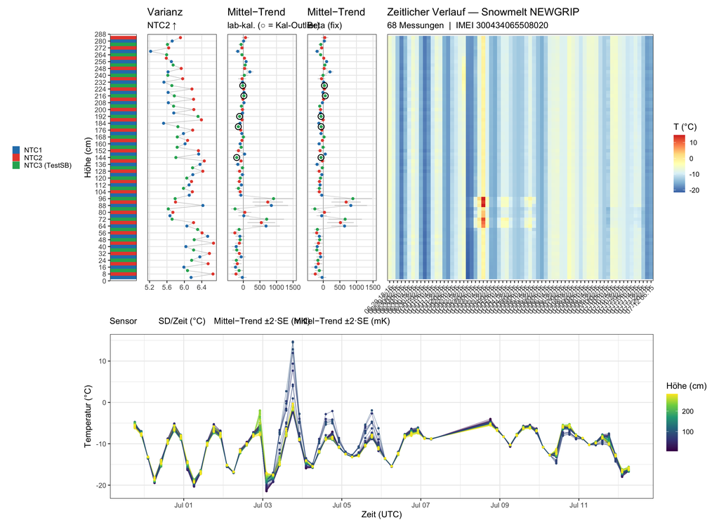

```r
# Two stacked panels over the same time series:
#  (top)    Hovmöller heatmap — Höhe (same axis as the profile plot) × time,
#           fill = temperature. Each measurement is one evenly-spaced column.
#  (bottom) Line plot — temperature vs real time, one line per sensor height,
#           coloured by Höhe; reads the diurnal cooling directly.
s   <- cfg$spacing_cm
ts  <- series_long |>
  mutate(
    sensor    = recode(sensor, ntc1_C = "NTC1", ntc2_C = "NTC2", testSB_C = "NTC3 (TestSB)"),
    ntc_rank  = case_when(sensor == "NTC1" ~ 1L, sensor == "NTC2" ~ 2L, TRUE ~ 3L),
    hoehe_cm  = (node - 1L) * 3L * s + ntc_rank * s,
    height_id = paste(node, sensor)
  )
tlevels <- format(sort(unique(ts$time)), "%m-%d %H:%M")
ts  <- ts |> mutate(tlab = factor(format(time, "%m-%d %H:%M"), levels = tlevels))
max_h <- n_nodes * 3L * s

# Companion strip (left of the heatmap, same y-axis): sensor type at each height.
sensor_cols <- c(NTC1 = "#2980b9", NTC2 = "#e74c3c", "NTC3 (TestSB)" = "#27ae60")
strip_df <- expand.grid(node = seq_len(n_nodes), ntc_rank = 1:3) |>
  mutate(sensor   = factor(c("NTC1", "NTC2", "NTC3 (TestSB)")[ntc_rank],
                           levels = names(sensor_cols)),
         hoehe_cm = (node - 1L) * 3L * s + ntc_rank * s)

p_sensor <- ggplot(strip_df, aes(x = 1, y = hoehe_cm, fill = sensor)) +
  geom_tile() +
  scale_fill_manual(values = sensor_cols, name = NULL) +
  scale_y_continuous(name = "Höhe (cm)", limits = c(0, max_h),
                     breaks = seq(0, max_h, by = max(s, 8L)), expand = c(0, 0)) +
  scale_x_continuous(name = "Sensor", breaks = NULL, expand = c(0, 0)) +
  labs(title = " ", subtitle = " ") +
  theme_bw(base_size = 13) +
  theme(panel.grid = element_blank(), legend.position = "left",
        legend.key.size = unit(0.8, "lines"))

# Two companion curves on the same height axis (variance & mean−trend residual).
sensor_by_h <- strip_df |> select(hoehe_cm, sensor)

var_df <- ts |> group_by(hoehe_cm) |>
  summarise(sd_t = 1.4826 * mad(temp_C, na.rm = TRUE), .groups = "drop") |>
  left_join(sensor_by_h, by = "hoehe_cm") |> arrange(hoehe_cm)

# Mittel−Trend = per-height time-median minus a single LINEAR height trend, once
# with the lab calibration and once with the fixed Beta curve (from counts).
ts <- ts |> mutate(temp_beta = NTC_beta(counts))
lin_offset <- function(col) {
  d <- ts |> select(time, hoehe_cm, y = all_of(col)) |> filter(is.finite(y)) |>
    group_by(time) |> mutate(r = 1000 * (y - fitted(lm(y ~ hoehe_cm)))) |> ungroup()
  d |> group_by(hoehe_cm) |>
    summarise(off_mK = mean(r), se_mK = sd(r) / sqrt(n()), .groups = "drop") |>
    left_join(sensor_by_h, by = "hoehe_cm")
}
off_lab  <- lin_offset("temp_C")
off_beta <- lin_offset("temp_beta")
xr_off   <- range(c(off_lab$off_mK  + 2 * off_lab$se_mK,  off_lab$off_mK  - 2 * off_lab$se_mK,
                    off_beta$off_mK + 2 * off_beta$se_mK, off_beta$off_mK - 2 * off_beta$se_mK),
                  na.rm = TRUE)

ybreaks <- seq(0, max_h, by = max(s, 8L))
p_var <- ggplot(var_df, aes(sd_t, hoehe_cm)) +
  geom_path(colour = "grey75", linewidth = 0.3) +
  geom_point(aes(colour = sensor), size = 1.5) +
  scale_colour_manual(values = sensor_cols, guide = "none") +
  scale_y_continuous(name = NULL, limits = c(0, max_h), breaks = ybreaks, expand = c(0, 0)) +
  scale_x_continuous(name = "SD/Zeit (°C)") +
  labs(title = "Varianz", subtitle = "NTC2 ↑") +
  theme_bw(base_size = 13) +
  theme(axis.text.y = element_blank(), axis.ticks.y = element_blank(),
        panel.grid.minor = element_blank())

# NTC3 calibration outliers (nodes 71/77/80/50/51/26) at their NTC3-row heights.
cal_outlier_h <- c(144, 180, 192, 216, 228, 288)

mk_mean <- function(d, ttl, sub) {
  out <- d |> filter(hoehe_cm %in% cal_outlier_h)
  ggplot(d, aes(off_mK, hoehe_cm)) +
    geom_vline(xintercept = 0, colour = "grey60", linewidth = 0.3) +
    geom_errorbarh(aes(xmin = off_mK - 2 * se_mK, xmax = off_mK + 2 * se_mK),
                   height = 0, colour = "grey70", linewidth = 0.3) +
    geom_path(colour = "grey80", linewidth = 0.3) +
    geom_point(aes(colour = sensor), size = 1.5) +
    geom_point(data = out, shape = 21, size = 3.6, stroke = 0.9,
               colour = "black", fill = NA) +
    scale_colour_manual(values = sensor_cols, guide = "none") +
    scale_y_continuous(name = NULL, limits = c(0, max_h), breaks = ybreaks, expand = c(0, 0)) +
    scale_x_continuous(name = "Mittel−Trend ±2·SE (mK)", limits = xr_off) +
    labs(title = ttl, subtitle = sub) +
    theme_bw(base_size = 13) +
    theme(axis.text.y = element_blank(), axis.ticks.y = element_blank(),
          panel.grid.minor = element_blank())
}
p_mean_lab  <- mk_mean(off_lab,  "Mittel−Trend", "lab-kal. (○ = Kal-Outlier)")
p_mean_beta <- mk_mean(off_beta, "Mittel−Trend", "Beta (fix)")

p_heat <- ggplot(ts, aes(x = tlab, y = hoehe_cm, fill = temp_C)) +
  geom_tile() +
  scale_fill_distiller(palette = "RdYlBu", direction = -1, name = "T (°C)") +
  scale_y_continuous(name = NULL, limits = c(0, max_h),
                     breaks = seq(0, max_h, by = max(s, 8L)), expand = c(0, 0)) +
  labs(title    = sprintf("Zeitlicher Verlauf — %s", cfg$label),
       subtitle = sprintf("%d Messungen  |  IMEI %s", n_msg, imei),
       x = NULL) +
  theme_bw(base_size = 13) +
  theme(axis.text.x = element_text(angle = 45, hjust = 1),
        axis.text.y = element_blank(), axis.ticks.y = element_blank(),
        panel.grid  = element_blank())

p_line <- ggplot(ts, aes(x = time, y = temp_C,
                         group = height_id, colour = hoehe_cm)) +
  geom_line(alpha = 0.5, linewidth = 0.4) +
  geom_point(size = 1) +
  scale_colour_viridis_c(name = "Höhe (cm)") +
  labs(x = "Zeit (UTC)", y = "Temperatur (°C)") +
  theme_bw(base_size = 13)

(p_sensor + p_var + p_mean_lab + p_mean_beta + p_heat +
   plot_layout(widths = c(0.5, 1.3, 1.3, 1.3, 5))) / p_line +
  plot_layout(heights = c(3, 2))
```

## NTC2-Diagnose

NTC1 / NTC2 / NTC3 sind je Node quasi am selben Ort, sollten also denselben Tagesgang sehen. Hier wird geprüft, ob **NTC2 systematisch einen stärkeren Tagesgang** hat als die beiden anderen (beobachtet in frühen Felddaten).

```r
safe_amp <- function(x) { x <- x[is.finite(x)]; if (length(x) < 2L) NA_real_ else diff(range(x)) }

diag_long <- series_long |>
  mutate(sensor = recode(sensor, ntc1_C = "NTC1", ntc2_C = "NTC2", testSB_C = "NTC3"))

common_df <- diag_long |> group_by(time) |>
  summarise(common = mean(temp_C, na.rm = TRUE), .groups = "drop")

per_node <- diag_long |>
  left_join(common_df, by = "time") |>
  group_by(node, sensor) |>
  summarise(
    amp   = safe_amp(temp_C),
    slope = if (sum(is.finite(temp_C)) >= 2L)
              cov(temp_C, common, use = "complete.obs") / var(common) else NA_real_,
    .groups = "drop"
  )

amp_w <- per_node |> select(node, sensor, amp) |>
  pivot_wider(names_from = sensor, values_from = amp) |>
  mutate(ref = (NTC1 + NTC3) / 2, d = NTC2 - ref)

summary_tab <- per_node |> group_by(sensor) |>
  summarise(`Amplitude ⌀ (°C)` = mean(amp,   na.rm = TRUE),
            `Slope ⌀`          = mean(slope, na.rm = TRUE),
            `n Nodes`          = sum(!is.na(amp)), .groups = "drop")

n_ok       <- sum(!is.na(amp_w$d))
n_strong   <- sum(amp_w$NTC2 > amp_w$NTC1 & amp_w$NTC2 > amp_w$NTC3, na.rm = TRUE)
amp_diff   <- mean(amp_w$d, na.rm = TRUE)
pval       <- tryCatch(t.test(amp_w$NTC2, amp_w$ref, paired = TRUE)$p.value,
                       error = function(e) NA_real_)
ntc2_amp   <- summary_tab$`Amplitude ⌀ (°C)`[summary_tab$sensor == "NTC2"]
others_amp <- max(summary_tab$`Amplitude ⌀ (°C)`[summary_tab$sensor != "NTC2"])
ntc2_stronger <- isTRUE(ntc2_amp > others_amp) && isTRUE(!is.na(pval) && pval < 0.05)
```

```r
knitr::kable(summary_tab, digits = c(0, 2, 3, 0),
             caption = sprintf("Pro-Sensor-Mittel über %d Messungen", n_msg))
```

Pro-Sensor-Mittel über 68 Messungen

| sensor | Amplitude ⌀ (°C) | Slope ⌀ | n Nodes |
| --- | --- | --- | --- |
| NTC1 | 19.23 | 0.993 | 24 |
| NTC2 | 19.58 | 1.014 | 24 |
| NTC3 | 19.19 | 0.992 | 23 |

```r
col <- if (ntc2_stronger) "#e67e22" else "#2ecc71"
tag <- if (ntc2_stronger) "AUFFÄLLIG" else "unauffällig"
cat(sprintf(
  '<span style="color:%s">**%s**</span> — NTC2 vs. Mittel(NTC1, NTC3), paarweise je Node:\n\n',
  col, tag))
```

**AUFFÄLLIG** — NTC2 vs. Mittel(NTC1, NTC3), paarweise je Node:

```r
cat(sprintf("- Amplitude im Mittel **%+.2f °C** stärker als NTC1/NTC3.\n", amp_diff))
```

- Amplitude im Mittel **+0.37 °C** stärker als NTC1/NTC3.

```r
cat(sprintf("- NTC2 am stärksten in **%d / %d** Nodes.\n", n_strong, n_ok))
```

- NTC2 am stärksten in **16 / 23** Nodes.

```r
cat(sprintf("- Paired t-Test (Amplitude): **p = %s**.\n",
            if (is.na(pval)) "n/a" else formatC(pval, format = "g", digits = 2)))
```

- Paired t-Test (Amplitude): **p = 0.011**.

```r
cat(sprintf("\n%s\n",
  if (ntc2_stronger)
    "→ NTC2 zeigt einen systematisch stärkeren Tagesgang (wahrscheinlich Kanal-/Sensor-Effekt). Mit mehr vollen Tageszyklen bestätigen."
  else
    "→ Kein systematischer Mehr-Tagesgang von NTC2 in diesen Daten."))
```

→ NTC2 zeigt einen systematisch stärkeren Tagesgang (wahrscheinlich Kanal-/Sensor-Effekt). Mit mehr vollen Tageszyklen bestätigen.

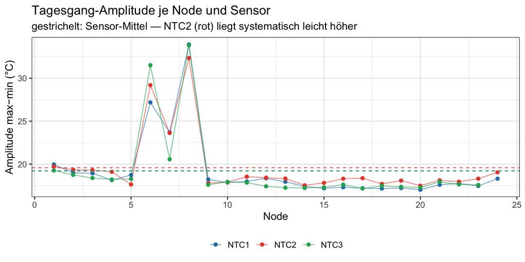

```r
ggplot(per_node, aes(x = node, y = amp, colour = sensor)) +
  geom_line(alpha = 0.6, linewidth = 0.5) +
  geom_point(size = 1.8) +
  geom_hline(data = summary_tab,
             aes(yintercept = `Amplitude ⌀ (°C)`, colour = sensor),
             linetype = "dashed", linewidth = 0.4, show.legend = FALSE) +
  scale_colour_manual(values = c(NTC1 = "#2980b9", NTC2 = "#e74c3c", NTC3 = "#27ae60")) +
  labs(title = "Tagesgang-Amplitude je Node und Sensor",
       subtitle = "gestrichelt: Sensor-Mittel — NTC2 (rot) liegt systematisch leicht höher",
       x = "Node", y = "Amplitude max−min (°C)", colour = NULL) +
  theme_bw(base_size = 13) +
  theme(legend.position = "bottom")
```

## Tape- & Alufolie-Experiment

An denselben oberen Knoten wurden nacheinander zwei **optische** Manipulationen angebracht: zuerst **schwarzes Tape** (absorbiert Sonne → heizt die Stäbe), später **Alufolie** (reflektiert Sonne → kühlt sie im Sonnenlicht). Beide zeigen sich klar als Solar-Anomalie (NTC1 − Median aller Knoten) der betroffenen Knoten — mit **entgegengesetztem Vorzeichen**.

| Behandlung | Knoten | von (UTC) | bis (UTC) | Solar-Signatur |
| --- | --- | --- | --- | --- |
| **Schwarztape** | 6, 7, 8 | Do 2026-07-02 22:00 | Mo 2026-07-06 00:00 | **+3 … +16 °C** (heizt) |
| **Alufolie** | 6, 7 | Do 2026-07-09 ~20:00 | So 2026-07-12 Nacht¹ | **−1 … −1.5 °C** (kühlt) |

¹ Zum Zeitpunkt der neuesten Nachricht (07-12 06:15) ist die Folie noch angebracht; die Entfernung Sonntag Nacht liegt nach dem letzten Datensatz. **Knoten 8** war nur getapt (keine Folie): im Folien-Fenster ist seine Anomalie ~0/erratisch (separates Kontakt-/Sitz-Problem) — foliert sind **Knoten 6 und 7**.

```r
BLACK_NODES <- c(6L, 7L, 8L)
ALU_NODES   <- c(6L, 7L)
win <- data.frame(
  treatment = c("Schwarztape", "Alufolie"),
  start = as.POSIXct(c("2026-07-02 22:00", "2026-07-09 20:00"), tz = "UTC"),
  end   = as.POSIXct(c("2026-07-06 00:00", "2026-07-12 22:00"), tz = "UTC"))

# Näherung Sonnenhöhe (Grad) am GRIP-Standort, ohne Paket.
solar_elev <- function(t, lat = 72.58, lon = -37.64) {
  doy  <- as.numeric(format(t, "%j", tz = "UTC"))
  hh   <- as.numeric(format(t, "%H", tz = "UTC")) + as.numeric(format(t, "%M", tz = "UTC")) / 60
  decl <- 23.45 * sin(2 * pi * (284 + doy) / 365) * pi / 180
  H    <- ((hh + lon / 15) - 12) * 15 * pi / 180; latr <- lat * pi / 180
  asin(sin(latr) * sin(decl) + cos(latr) * cos(decl) * cos(H)) * 180 / pi
}

# NTC1 pro Knoten & Zeit → Anomalie ggü. Median aller Knoten (= Umgebung).
ntc1_w  <- series_long |> filter(sensor == "ntc1_C") |> select(node, time, temp_C)
med     <- ntc1_w |> group_by(time) |>
  summarise(refT = median(temp_C, na.rm = TRUE), .groups = "drop")
anom_df <- ntc1_w |> left_join(med, by = "time") |>
  mutate(anom  = temp_C - refT,
         elev  = solar_elev(time),
         phase = factor(case_when(
           time <  win$start[1] ~ "vor",
           time <  win$end[1]   ~ "Schwarztape",
           time <  win$start[2] ~ "zwischen",
           time <  win$end[2]   ~ "Alufolie",
           TRUE                 ~ "nach"),
           levels = c("vor", "Schwarztape", "zwischen", "Alufolie", "nach")))
```

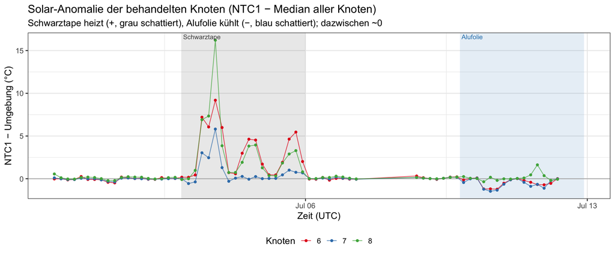

```r
treated <- anom_df |> filter(node %in% union(BLACK_NODES, ALU_NODES)) |>
  mutate(Knoten = factor(node))
ggplot(treated, aes(time, anom, colour = Knoten, group = node)) +
  annotate("rect", xmin = win$start[1], xmax = win$end[1], ymin = -Inf, ymax = Inf,
           fill = "grey30", alpha = 0.12) +
  annotate("rect", xmin = win$start[2], xmax = win$end[2], ymin = -Inf, ymax = Inf,
           fill = "#2980b9", alpha = 0.12) +
  geom_hline(yintercept = 0, colour = "grey70") +
  geom_line(alpha = 0.7) + geom_point(size = 1.3) +
  annotate("text", x = win$start[1], y = Inf, label = " Schwarztape", hjust = 0,
           vjust = 1.4, size = 3.2, colour = "grey30") +
  annotate("text", x = win$start[2], y = Inf, label = " Alufolie", hjust = 0,
           vjust = 1.4, size = 3.2, colour = "#2980b9") +
  scale_colour_brewer(palette = "Set1") +
  labs(title = "Solar-Anomalie der behandelten Knoten (NTC1 − Median aller Knoten)",
       subtitle = "Schwarztape heizt (+, grau schattiert), Alufolie kühlt (−, blau schattiert); dazwischen ~0",
       x = "Zeit (UTC)", y = "NTC1 − Umgebung (°C)") +
  theme_bw(base_size = 13) + theme(legend.position = "bottom")
```

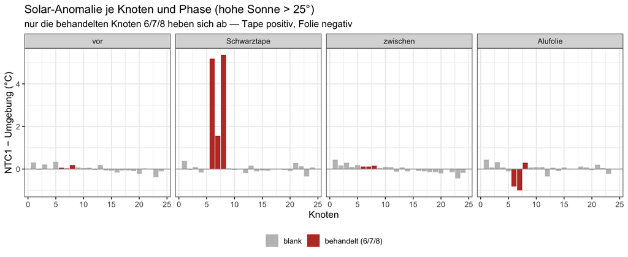

```r
phase_tab <- anom_df |>
  filter(elev > 25, phase %in% c("vor", "Schwarztape", "zwischen", "Alufolie")) |>
  group_by(node, phase) |>
  summarise(anom = mean(anom, na.rm = TRUE), .groups = "drop") |>
  mutate(behandelt = node %in% union(BLACK_NODES, ALU_NODES))
ggplot(phase_tab, aes(node, anom, fill = behandelt)) +
  geom_col() +
  geom_hline(yintercept = 0, colour = "grey60") +
  facet_wrap(~ phase, nrow = 1) +
  scale_fill_manual(values = c(`FALSE` = "grey75", `TRUE` = "#c0392b"),
                    labels = c("blank", "behandelt (6/7/8)"), name = NULL) +
  labs(title = "Solar-Anomalie je Knoten und Phase (hohe Sonne > 25°)",
       subtitle = "nur die behandelten Knoten 6/7/8 heben sich ab — Tape positiv, Folie negativ",
       x = "Knoten", y = "NTC1 − Umgebung (°C)") +
  theme_bw(base_size = 12) + theme(legend.position = "bottom")
```

```r
hs     <- anom_df |> filter(elev > 25, node %in% ALU_NODES)
ph_m   <- function(p) mean(hs$anom[hs$phase == p], na.rm = TRUE)
cat(sprintf("**Ja — deutlich sichtbar, mit umgekehrtem Vorzeichen zum Tape.** Knoten 6/7 bei hoher Sonne (>25°) im Mittel: **vor %+.2f °C**, **Schwarztape %+.2f °C**, **zwischen %+.2f °C**, **Alufolie %+.2f °C**. Die reflektierende Folie kühlt die Stäbe im Sonnenlicht (weniger absorbierte Strahlung), während das schwarze Tape sie als Schwarzkörper aufheizte. Onset der Folie exakt in der Nacht Do→Fr (erste Hochsonnen-Nachricht 07-10 10:15 bereits ≈ −1.2 °C).\n",
            ph_m("vor"), ph_m("Schwarztape"), ph_m("zwischen"), ph_m("Alufolie")))
```

**Ja — deutlich sichtbar, mit umgekehrtem Vorzeichen zum Tape.** Knoten 6/7 bei hoher Sonne (>25°) im Mittel: **vor +0.05 °C**, **Schwarztape +3.37 °C**, **zwischen +0.12 °C**, **Alufolie -0.91 °C**. Die reflektierende Folie kühlt die Stäbe im Sonnenlicht (weniger absorbierte Strahlung), während das schwarze Tape sie als Schwarzkörper aufheizte. Onset der Folie exakt in der Nacht Do→Fr (erste Hochsonnen-Nachricht 07-10 10:15 bereits ≈ −1.2 °C).

## Save result

```r
# Newest message → per-node table.
slug    <- if (use_bin) tools::file_path_sans_ext(basename(primary_file)) else paste0("imei", imei)
outfile <- sprintf("data/decoded_%s_%s.csv", slug, format(time_utc, "%Y%m%d_%H%M%S"))
write.csv(nodes, outfile, row.names = FALSE)
cat("Saved:", outfile, "\n")
```

```
Saved: data/decoded_300434065508020-78_20260712_061557.csv
```

```r
# Whole time series → one long CSV (time, node, sensor, temp_C).
if (exists("multi") && multi) {
  ts_file <- sprintf("data/series_imei%s_%s.csv", imei, format(time_utc, "%Y%m%d_%H%M%S"))
  write.csv(series_long, ts_file, row.names = FALSE)
  cat("Saved series:", ts_file, "\n")
}
```

```
Saved series: data/series_imei300434065508020_20260712_061557.csv
```